Return to Main Page

[figure not shown]

[figure not shown]

```r
library(tidyverse)
library(gapminder)
```

[Import Cheatsheet](https://github.com/social-lorax/howto_codebooks/blob/master/cheatsheets/data-import.pdf)

# $\color{darkblue}{\textbf{Data in R}}$

### $\color{dodgerblue}{\textbf{Equity}}$

- Where does this data come from?
- Why was this data collected?
- How was this data generated?
- Is this data demographically representative?
- Who is included and who is excluded from this data?
- Whose voices, lives, and experiences are missing?
- How much can this data be disaggregated by race, gender, ethnicity, etc.?
- Are the categories mutually exclusive and fully inclusive?
- Are there “other” categories and, if so, who does that include?
- Who stands to benefit from this data?
- Who might be harmed by the collection or publication of this data?

(See more in Urban Institute’s [Do No Harm Guide](https://www.urban.org/research/publication/do-no-harm-guide-applying-equity-awareness-data-visualization/view/full_report))

### $\color{dodgerblue}{\textbf{Tibbles}}$

Tibbles *are* data frames, but they tweak some older behaviors to make life a little easier:

- Tibbles have a refined `print()` method that shows only the first 10 rows and all the columns that fit on screen.
- Tibbles allow you to subset using `$` or `[[]]`.

`as_tibble()` transforms existing data into a tibble

```r
data %>%
  as_tibble()
```

`tibble()` creates a tibble from new data

```r
tibble(x = 1:5,
       y = 1,
       z = x ^ 2 + y)
```

# $\color{darkblue}{\textbf{Importing}}$

### $\color{dodgerblue}{\textbf{Basic Files (readr)}}$

`readr` (part of tidyverse) covers basics like csv files

- `skip = n` skips the first `n` lines
- `comment = "#"` drops all lines that start with (e.g.) `#`
- `col_names = FALSE` tells read_csv() not to treat the first row as headings and instead label them from `X1` to `Xn`
- `col_names = c("x", "y", "z")` renames the columns as the character vector
- `col_types = cols()` reads in the columns as the specified data type
- `na = 999` replaces dataset-specific NA values (e.g., 999) as `NA`

```r
read_csv("path/to/file.csv")

read_rds("path/to/file.rds")

read_delim("path/to/file.txt", delim = ";")
```

```r
#Best Practice
csv_data <- read_csv("path/to/file.csv",
                     col_types = cols(w = col_double(),
                                      x = col_date(format = ""),
                                      y = col_character(),
                                      z = col_logical()))
```

### $\color{dodgerblue}{\textbf{Other Files}}$

#### $\color{skyblue}{\textrm{- Stats (haven)}}$

`haven` reads SPSS, Stata, and SAS files

```r
library(haven)

read_sas("path/to/file.sas7bdat")

read_spss("path/to/file.spv")

read_stata("path/to/file.dta")
```

#### $\color{skyblue}{\textrm{- Excel (readxl)}}$

`readxl` reads excel files (both .xls and .xlsx)

```r
library(readxl)

read_excel("path/to/file.xlsx")
```

#### $\color{skyblue}{\textrm{- Databases (DBI)}}$

`DBI`, along with a database specific backend (e.g. RMySQL, RSQLite, RPostgreSQL etc), runs SQL queries (See SQL)

```r
library(DBI)

con <- "connection to database"

dbGetQuery(con, "

  SELECT *
    FROM table

           ") %>% as_tibble()
```

#### $\color{skyblue}{\textrm{- JSON Files (jsonlite)}}$

`jsonlite` reads json files

#### $\color{skyblue}{\textrm{- XML Files (xml2)}}$

`xml2` reads XML

# $\color{darkblue}{\textbf{Exporting}}$

`write_csv()` exports a plain csv

```r
write_csv(dataset, "path/dataset.csv")
```

`write_rds()` preserves formatting as an rds file

```r
write_rds(dataset, "path/dataset.rds")
```

# $\color{darkblue}{\textbf{Checking Data}}$

### $\color{dodgerblue}{\textbf{Contents}}$

`print()` (or just calling it) checks the size

```r
gapminder
```

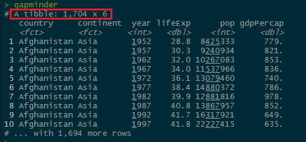

`names()` gives a list of all of the columns

```r
gapminder %>%
  names()
```

```
[1] "country"   "continent" "year"      "lifeExp"   "pop"       "gdpPercap"
```

`distinct` gives a list of all unique values in a specified column

```r
gapminder %>% distinct(continent)
```

| continent |
| --- |
| Asia |
| Europe |
| Africa |
| Americas |
| Oceania |

### $\color{dodgerblue}{\textbf{Summarizing}}$

#### $\color{skyblue}{\textrm{- Statistics}}$

`summary()` gives basic stats on numeric columns, but I prefer this custom function

```r
col_summaries <- function(.data){

  all_cols <- .data %>% names()

  test_col <- function(.test_col){
    test_data <- .data %>%
      as_tibble() %>%
      rename(test = .test_col) %>%
      mutate_if(is.logical, as.character)

    if(dim(test_data %>% filter(!is.na(test)))[1] == 0){
      test_data %>%
        summarize(column = .test_col,
                  type = class(test_data$test),
                  missing = sum(is.na(test)),
                  unique_values = NA_real_,
                  example = NA_character_,
                  min = NA_real_,
                  q25 = NA_real_,
                  median = NA_real_,
                  q75 = NA_real_,
                  max = NA_real_)
    } else if(class(test_data$test) %in% c("integer", "numeric")){
      test_data %>%
        summarize(column = .test_col,
                  type = class(test_data$test),
                  missing = sum(is.na(test)),
                  unique_values = NA_real_,
                  example = NA_character_,
                  min = min(test, na.rm = TRUE),
                  q25 = quantile(test, 0.25, na.rm = TRUE),
                  median = median(test, na.rm = TRUE),
                  q75 = quantile(test, 0.75, na.rm = TRUE),
                  max = max(test, na.rm = TRUE))
    } else {
      test_data %>%
        summarize(column = .test_col,
                  type = class(test_data$test),
                  missing = sum(is.na(test)),
                  unique_values = n_distinct(test)) %>%
        bind_cols(test_data %>%
                    filter(!is.na(test)) %>%
                    select(test) %>%
                    head(1) %>%
                    rename(example = test)) %>%
        mutate(min = NA_real_,
               q25 = NA_real_,
               median = NA_real_,
               q75 = NA_real_,
               max = NA_real_ )
      }
    }

  map_dfr(all_cols, test_col)
}
```

```r
gapminder %>%
  col_summaries()
```

| column | type | missing | unique_values | example | min | q25 | median | q75 | max |
| --- | --- | --- | --- | --- | --- | --- | --- | --- | --- |
| country | factor | 0 | 142 | Afghanistan | NA | NA | NA | NA | NA |
| continent | factor | 0 | 5 | Asia | NA | NA | NA | NA | NA |
| year | integer | 0 | NA | NA | 1952.0000 | 1965.750 | 1979.5000 | 1.993250e+03 | 2.007000e+03 |
| lifeExp | numeric | 0 | NA | NA | 23.5990 | 48.198 | 60.7125 | 7.084550e+01 | 8.260300e+01 |
| pop | integer | 0 | NA | NA | 60011.0000 | 2793664.000 | 7023595.5000 | 1.958522e+07 | 1.318683e+09 |
| gdpPercap | numeric | 0 | NA | NA | 241.1659 | 1202.060 | 3531.8470 | 9.325462e+03 | 1.135231e+05 |

#### $\color{skyblue}{\textrm{- Cross Tabs}}$

`table()` creates a cross tab count

```r
gap_07 <- gapminder %>%
  filter(year==2007) %>%
  mutate(country_size = case_when(pop > 3.121e+07 ~ "large",
                                  pop < 4.508e+06 ~ "small",
                                  TRUE            ~ "average"),
         country_size = factor(country_size,
                               ordered = TRUE,
                               levels = c("large", "average", "small")))

table(gap_07$continent, gap_07$country_size)
```

```
           large average small
  Africa      10      25    17
  Americas     6      13     6
  Asia        13      14     6
  Europe       7      17     6
  Oceania      0       1     1
```

#### $\color{skyblue}{\textrm{- Frequency Tables}}$

`prop.table()` creates a frequency table, but I prefer this custom function for formatting

```r
gap_07 <- gapminder %>%
  filter(year==2007) %>%
  mutate(country_size = case_when(pop > 3.121e+07 ~ "large",
                                  pop < 4.508e+06 ~ "small",
                                  TRUE            ~ "average"),
         country_size = factor(country_size,
                               ordered = TRUE,
                               levels = c("large", "average", "small")))

size_table <- table(gap_07$continent, gap_07$country_size)

props <- function(col1, col2, prop_type){
  cross_tab <- table(col1, col2)

  if(prop_type == "overall"){
    prop.table(cross_tab) %>%
      as.data.frame() %>%
      as_tibble() %>%
      spread(col2, Freq) %>%
      janitor::adorn_totals("col") %>%
      janitor::adorn_totals("row") %>%
      as_tibble() %>%
      mutate_at(vars(-col1), scales::percent, accuracy = 0.1) %>%
      rename(` ` = col1)
  } else if(prop_type == "row"){
    prop.table(cross_tab, 2) %>%
      as.data.frame() %>%
      as_tibble() %>%
      spread(col2, Freq) %>%
      janitor::adorn_totals("row") %>%
      as_tibble() %>%
      mutate_at(vars(-col1), scales::percent, accuracy = 0.1) %>%
      rename(` ` = col1)
  } else{
    prop.table(cross_tab, 1) %>%
      as.data.frame() %>%
      as_tibble() %>%
      spread(col2, Freq) %>%
      janitor::adorn_totals("col") %>%
      as_tibble() %>%
      mutate_at(vars(-col1), scales::percent, accuracy = 0.1) %>%
      rename(` ` = col1)
  }
}
```

```r
#Overall Proportions
props(gap_07$continent, gap_07$country_size, "overall")
```

|  | large | average | small | Total |
| --- | --- | --- | --- | --- |
| Africa | 7.0% | 17.6% | 12.0% | 36.6% |
| Americas | 4.2% | 9.2% | 4.2% | 17.6% |
| Asia | 9.2% | 9.9% | 4.2% | 23.2% |
| Europe | 4.9% | 12.0% | 4.2% | 21.1% |
| Oceania | 0.0% | 0.7% | 0.7% | 1.4% |
| Total | 25.4% | 49.3% | 25.4% | 100.0% |

```r
#Column Proportions
props(gap_07$continent, gap_07$country_size, "col")
```

|  | large | average | small | Total |
| --- | --- | --- | --- | --- |
| Africa | 19.2% | 48.1% | 32.7% | 100.0% |
| Americas | 24.0% | 52.0% | 24.0% | 100.0% |
| Asia | 39.4% | 42.4% | 18.2% | 100.0% |
| Europe | 23.3% | 56.7% | 20.0% | 100.0% |
| Oceania | 0.0% | 50.0% | 50.0% | 100.0% |

```r
#Row Proportions
props(gap_07$continent, gap_07$country_size, "row")
```

|  | large | average | small |
| --- | --- | --- | --- |
| Africa | 27.8% | 35.7% | 47.2% |
| Americas | 16.7% | 18.6% | 16.7% |
| Asia | 36.1% | 20.0% | 16.7% |
| Europe | 19.4% | 24.3% | 16.7% |
| Oceania | 0.0% | 1.4% | 2.8% |
| Total | 100.0% | 100.0% | 100.0% |

#### $\color{skyblue}{\textrm{- Correlation Tables}}$

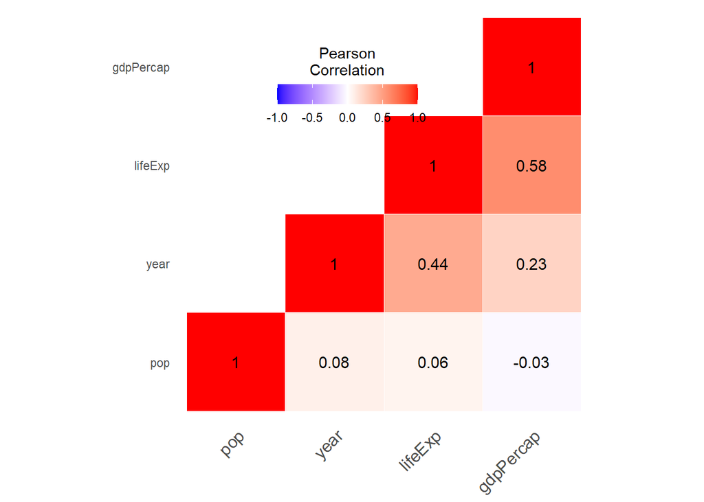

```r
library(reshape2)

get_pretty_cormap <- function (.data, .numcols) {
  cormat <- round(cor(select(.data, .numcols)), 2)

  reorder_cormat <- function(cormat){
    dd <- as.dist((1-cormat)/2)
    hc <- hclust(dd)
    cormat <-cormat[hc$order, hc$order]}
  cormat <- reorder_cormat(cormat)

  get_upper_tri <- function(cormat){
    cormat[lower.tri(cormat)]<- NA
    return(cormat)}
  upper_tri <- get_upper_tri(cormat)

  melted_cormat <- melt(upper_tri, na.rm = TRUE)

  ggplot(melted_cormat, aes(Var2, Var1, fill = value)) +
    geom_tile(color = "white") +
    scale_fill_gradient2(low = "blue", high = "red", mid = "white", midpoint = 0, limit = c(-1,1),
                         space = "Lab", name = "Pearson\nCorrelation") +
    theme_minimal() +
    theme(axis.text.x = element_text(angle = 45, vjust = 1, size = 12, hjust = 1)) +
    coord_fixed() +
    geom_text(aes(Var2, Var1, label = value), color = "black", size = 4) +
    theme(axis.title.x = element_blank(),
          axis.title.y = element_blank(),
          panel.grid.major = element_blank(),
          panel.border = element_blank(),
          panel.background = element_blank(),
          axis.ticks = element_blank(),
          legend.justification = c(1, 0),
          legend.position = c(0.6, 0.7),
          legend.direction = "horizontal") +
    guides(fill = guide_colorbar(barwidth = 7, barheight = 1, title.position = "top", title.hjust = 0.5))}

get_pretty_cormap(gapminder, c("year", "lifeExp", "pop", "gdpPercap"))
```

### $\color{dodgerblue}{\textbf{Missing Values}}$

#### $\color{skyblue}{\textrm{- Setting NA}}$

`na =` or `recode()` sets what counts as missing

```r
#When importing
dataframe <- read_csv("datasource.csv",
                      na = c("", "NA", "UNKNOWN", 999))

#When already read-in
dateframe <- dataframe %>%
  mutate(char_col = recode(char_col, "NA" = NA_character_),
         num_col = recode(num_col, 999 = NA_integer_))
```

#### $\color{skyblue}{\textrm{- Checking for NAs}}$

`any(is.na())` checks whether there are ANY missing values

```r
#Overall
any(is.na(gapminder))
```

```
[1] FALSE
```

```r
#In a specific column
any(is.na(gapminder$lifeExp))
```

```
[1] FALSE
```

`summarize(sum(is.na()))` counts the missing values within each column

```r
gapminder %>%
  summarize(observations = n(),
            missing_lifeExp = sum(is.na(lifeExp)))
```

| observations | missing_lifeExp |
| --- | --- |
| 1704 | 0 |

```r
expected <- c("Africa" = 54,
              "Americas" = 35,
              "Asia" = 47,
              "Europe" = 43,
              "Oceania" = 14)

gapminder %>%
  filter(year == 2007) %>%
  group_by(continent) %>%
  summarize(countries_represented = n()) %>%
  mutate(countries_expected = expected[continent],
         missing_countries = countries_expected - countries_represented)
```

| continent | countries_represented | countries_expected | missing_countries |
| --- | --- | --- | --- |
| Africa | 52 | 54 | 2 |
| Americas | 25 | 35 | 10 |
| Asia | 33 | 47 | 14 |
| Europe | 30 | 43 | 13 |
| Oceania | 2 | 14 | 12 |

#### $\color{skyblue}{\textrm{- Removing NAs}}$

`filter(!is.na())` removes entire rows with missing values in the specified column

```r
gapminder %>%
  filter(!is.na(lifeExp)) %>%
  head()
```

| country | continent | year | lifeExp | pop | gdpPercap |
| --- | --- | --- | --- | --- | --- |
| Afghanistan | Asia | 1952 | 28.801 | 8425333 | 779.4453 |
| Afghanistan | Asia | 1957 | 30.332 | 9240934 | 820.8530 |
| Afghanistan | Asia | 1962 | 31.997 | 10267083 | 853.1007 |
| Afghanistan | Asia | 1967 | 34.020 | 11537966 | 836.1971 |
| Afghanistan | Asia | 1972 | 36.088 | 13079460 | 739.9811 |
| Afghanistan | Asia | 1977 | 38.438 | 14880372 | 786.1134 |

`replace_na()` replaces missing values

```r
gapminder %>%
  mutate(pop = replace_na(pop, 0)) %>%
  head()
```

| country | continent | year | lifeExp | pop | gdpPercap |
| --- | --- | --- | --- | --- | --- |
| Afghanistan | Asia | 1952 | 28.801 | 8425333 | 779.4453 |
| Afghanistan | Asia | 1957 | 30.332 | 9240934 | 820.8530 |
| Afghanistan | Asia | 1962 | 31.997 | 10267083 | 853.1007 |
| Afghanistan | Asia | 1967 | 34.020 | 11537966 | 836.1971 |
| Afghanistan | Asia | 1972 | 36.088 | 13079460 | 739.9811 |
| Afghanistan | Asia | 1977 | 38.438 | 14880372 | 786.1134 |

### $\color{dodgerblue}{\textbf{Duplicates}}$

`distinct()` keeps unique rows and removes all others that are completely identical

```r
data %>%
  distinct()
```

`distinct(col, .keep_all = TRUE)` (adding a column as an argument) just looks at the values within that column regardless of whether the other columns are the same (this will keep the first occurrence, so arrange as desired first)

```r
data %>%
  distinct(col, .keep_all = TRUE)
```

```r
#Most recent entry for each country
gapminder %>%
  arrange(desc(year)) %>%
  distinct(country, .keep_all = TRUE) %>%
  head()
```

| country | continent | year | lifeExp | pop | gdpPercap |
| --- | --- | --- | --- | --- | --- |
| Afghanistan | Asia | 2007 | 43.828 | 31889923 | 974.5803 |
| Albania | Europe | 2007 | 76.423 | 3600523 | 5937.0295 |
| Algeria | Africa | 2007 | 72.301 | 33333216 | 6223.3675 |
| Angola | Africa | 2007 | 42.731 | 12420476 | 4797.2313 |
| Argentina | Americas | 2007 | 75.320 | 40301927 | 12779.3796 |
| Australia | Oceania | 2007 | 81.235 | 20434176 | 34435.3674 |

### $\color{dodgerblue}{\textbf{Outliers}}$

Causes:

- Valid measurements that happen to be extreme
- Variability in measurement
- Experimental error
- Data entry error

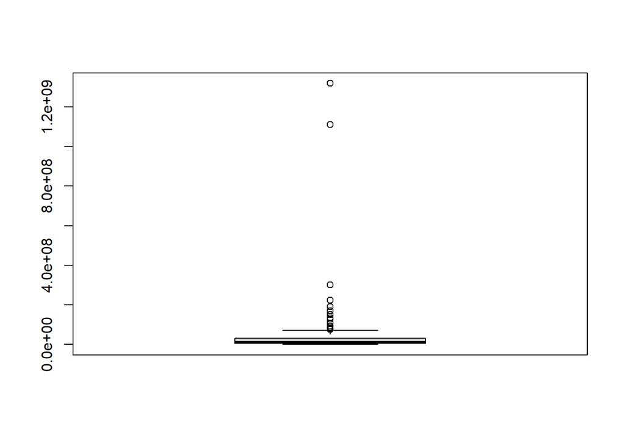

```r
boxplot(gap_07$pop)
```

All of the circles are technically outliers. We know that the two extremes (China and India) are, in fact, correct. If there was a third, that was that extreme, it would be an error that should be removed or replaced. Similarly, if there was a negative population, that would also be an error that should be removed or replaced.

Return to Main Page